# Intro to Jupyter Notebooks!

Adapted from:  
https://github.com/Summer-MIND/mind_2018/tree/master/tutorials/jupyter  
https://github.com/adam-p/markdown-here/wiki/Markdown-Cheatsheet

[figure not shown]

Source: https://www.benfrederickson.com/ranking-programming-languages-by-github-users/

## Interactive Coding

- Rather than keeping code scripts code and execution separate, jupyter integrates both together using the concept of code cells
- Cells pair "snippets" of code with the output obtained from running them
- Can contain plots/figure inline alongside code required to generate them

```python
# This is a cell
#Put some code here and get some output below!
x = 10
print(x)
```

```
10
```

This is a *markdown* **cell**!

```python
#Put more code here!
z = 40
print("x = " + str(x))
print("z = " + str(z))
```

```
x = 10
z = 40
```

## Notebooks of the Future

### Not just for code:

- Markdown, HTML, LateX integration
- Slide shows (like this one!)
- Keep your notes alongside your analysis routines
- Embed images, videos, anything (it's all just HTML + javascript)

### HTML Integration:

| **subIDs** | **data** |
| --- | --- |
| Cell 1 | Cell 2 |
| Cell 3 | Cell 4 |

### LaTeX Integration:

Compute the following:
$$\sum_{n=1}^{5}n$$

```python
sum = 0
for n in [1,2,3,4,5]:
    sum = sum + n
print(sum)
```

```
15
```

```python
from IPython.display import display, Image

display(Image('https://raw.githubusercontent.com/Summer-MIND/mind_2018/master/tutorials/jupyter/demo.gif'))
```

[output not shown]

# Multilingual!

- Python (multiple versions together)
- R
- Matlab
- Javascript
- etc (https://github.com/jupyter/jupyter/wiki/Jupyter-kernels)

### R

```python
import rpy2.rinterface
%load_ext rpy2.ipython
```

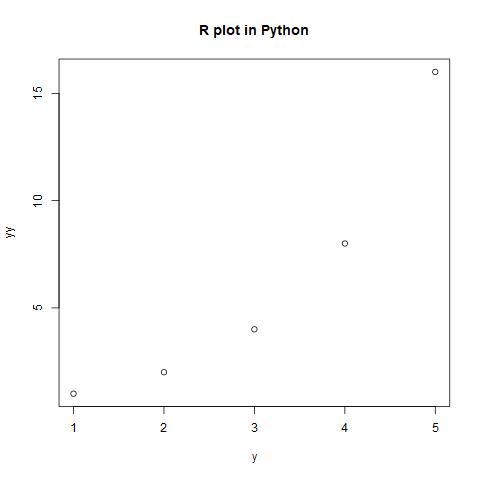

```python
%%R

y <- c(1,2,3,4,5)
yy <- c(1,2,4,8,16)

plot(y,
     yy,
     main='R plot in Python')
```

The cell below will add our variables x=10 and z=40 together using R, and then output the sum as the variable XZ

```python
%%R -i x -i z -o XZ

XZ <- x + z
```

The cell below will return XZ in Python! Cool, huh?!

```python
print(XZ)
```

```
[1] 50
```

### MATLAB (because we like paying for licenses)

```python
%load_ext pymatbridge
```

```
Starting MATLAB on ZMQ socket tcp://127.0.0.1:53207
Send 'exit' command to kill the server
.....MATLAB started and connected!
```

```python
%%matlab
disp('This is a matlab cell')
```

```
This is a matlab cell
```

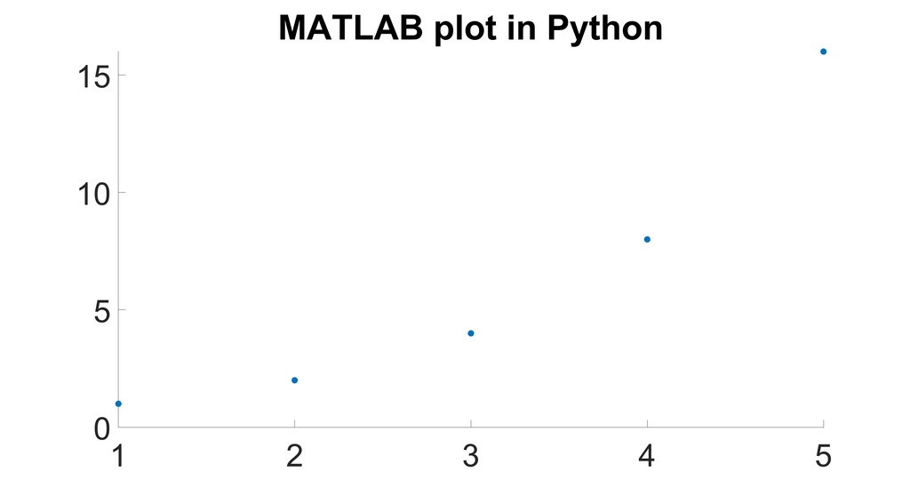

```python
%%matlab

y = [1,2,3,4,5];
yy = [1,2,4,8,16];

scatter(y,yy,100,'filled');
title('MATLAB plot in Python');
set(gca, 'FontSize', 50);
```

## The best part? Talking across languages!

```python
X = %R c(1,2,3,4,5,6)
X *= 10
print("Look now I'm a NumPy array!")
X
```

```
Look now I'm a NumPy array!
```

```
array([10., 20., 30., 40., 50., 60.])
```

```python
exit
```

## Save notebooks in other formats and put them online

- Github automatically renders jupyter notebooks
- <a href= "http://nbviewer.jupyter.org/">Online notebook viewer</a>
- Output to PDF, HTML (including javascript)
- [Jupyterhub](https://github.com/jupyterhub/jupyterhub): code with friends!

## Customize your notebook experience with extensions

- Table of Contents
- Execution time/Profiling
- Scratch Space
- Code/Section folding
- Look and feel (CSS+Javascript)
- [Other notebook extensions](https://github.com/ipython-contrib/jupyter_contrib_nbextensions)

## For more...

- [Eshin Jolly - Intro to Jupyter Notebooks](https://github.com/Summer-MIND/mind_2018/tree/master/tutorials/jupyter)
- [Jake Vanderplas - Data Science Handbook](https://github.com/jakevdp/PythonDataScienceHandbook)
- [Tal Yarkoni - Intro to Data Science w/ Python](https://github.com/tyarkoni/SSI2016)
- [Yarik - Intro to Programming for Psych/Neuro](https://github.com/dartmouth-pbs/psyc161)
- [Awesome notebooks](https://github.com/jupyter/jupyter/wiki/A-gallery-of-interesting-Jupyter-Notebooks)
- [Neuroimaging in Python](https://github.com/datacarpentry/python-neuroimaging-lesson)
- [Google Colaboratory](https://colab.research.google.com/notebooks/welcome.ipynb#recent=true)

# Thanks!

```python
!jupyter nbconvert 01_jupyter.ipynb --to slides --post serve
```